# Introduction to Modern Mathematical Modeling: A User’s Manual to Train Mathematical Consultants

**A Cambridge University Press book by Samuel S.P. Shen**

**The computer codes of this book were edited and proofread by Joaquin Stawsky and Momtaza Sayd.**

## Chapter 3: Linear Models using Regression and Data

### DataFrames, reading file input, and pandas!

Often, it is necessary to read information from a file to analyze it. For that, one of the more useful python packages is 'pandas'. pandas has functions that allow for the input of files from your computer, but also allows you to store the data in something called a DataFrame, which is a data structure that is similar to a 2d array but with other 'Quality of Life' features that make grouping and indexing the data easier.

```python
import pandas as pd
import numpy as np
import matplotlib.pyplot as plt
import os
# In addition to the import of pandas as pd, we've also imported numpy and
# matplotlib. Both of those packages are immensely useful tools, as
# stated in chapter 2, so you'll very likely see them in every chapter from
# here on out. Moreover, the os package is used for accessing the operating
# system of the computer.
```

```python
os.chdir(r"C:\Users\HP\Documents\sshen\mathmodel\data")
globalLifeExpectancy = \
    pd.read_csv("API_SP.DYN.LE00.IN_DS2_en_csv_v2_4330149.csv",
                                   header=2, index_col=0)
# May be necessary to redownload the files from the link in the cell below
# and place it in the correct directory specified above.
globalLifeExpectancy
# Above we use our pandas import to read a csv file (csv is short for Comma
# Separated Values, a very common file type for data storage) and store it's
# data in a DataFrame called globalLifeExpectancy. The first argument to the
# function is the name of the file (given as a string), the second argument
# is a keyword argument specifying the number of lines in the 'header' of
# the file. Some csv files will have multiline headers that explains the data
# in the file, and in this case there are 2. The third argument specifies
# which column's data will be used to label each row, more on these 'labels'
# momentarily.
```

| Country Name | Country Code | Indicator Name | Indicator Code | 1960 | 1961 | 1962 | 1963 | 1964 | 1965 | 1966 | ... | 2013 | 2014 | 2015 | 2016 | 2017 | 2018 | 2019 | 2020 | 2021 | Unnamed: 66 |
| --- | --- | --- | --- | --- | --- | --- | --- | --- | --- | --- | --- | --- | --- | --- | --- | --- | --- | --- | --- | --- | --- |
| Aruba | ABW | Life expectancy at birth, total (years) | SP.DYN.LE00.IN | 65.662000 | 66.074000 | 66.444000 | 66.787000 | 67.113000 | 67.435000 | 67.762000 | ... | 75.441000 | 75.583000 | 75.725000 | 75.868000 | 76.010000 | 76.152000 | 76.293000 | 76.434000 | NaN | NaN |
| Africa Eastern and Southern | AFE | Life expectancy at birth, total (years) | SP.DYN.LE00.IN | 42.716053 | 43.166935 | 43.603990 | 44.025617 | 44.432721 | 44.826919 | 45.213048 | ... | 60.953363 | 61.647367 | 62.259288 | 62.787681 | 63.246264 | 63.648988 | 64.005213 | 64.325702 | NaN | NaN |
| Afghanistan | AFG | Life expectancy at birth, total (years) | SP.DYN.LE00.IN | 32.446000 | 32.962000 | 33.471000 | 33.971000 | 34.463000 | 34.948000 | 35.430000 | ... | 62.525000 | 62.966000 | 63.377000 | 63.763000 | 64.130000 | 64.486000 | 64.833000 | 65.173000 | NaN | NaN |
| Africa Western and Central | AFW | Life expectancy at birth, total (years) | SP.DYN.LE00.IN | 37.205380 | 37.632546 | 38.052612 | 38.463746 | 38.867073 | 39.264841 | 39.662762 | ... | 55.618986 | 56.088269 | 56.542009 | 56.974761 | 57.382363 | 57.762347 | 58.115723 | 58.445953 | NaN | NaN |
| Angola | AGO | Life expectancy at birth, total (years) | SP.DYN.LE00.IN | 37.524000 | 37.811000 | 38.113000 | 38.430000 | 38.760000 | 39.102000 | 39.454000 | ... | 58.054000 | 58.776000 | 59.398000 | 59.925000 | 60.379000 | 60.782000 | 61.147000 | 61.487000 | NaN | NaN |
| ... | ... | ... | ... | ... | ... | ... | ... | ... | ... | ... | ... | ... | ... | ... | ... | ... | ... | ... | ... | ... | ... |
| Kosovo | XKX | Life expectancy at birth, total (years) | SP.DYN.LE00.IN | NaN | NaN | NaN | NaN | NaN | NaN | NaN | ... | 70.797561 | 71.097561 | 71.346341 | 71.846341 | 72.295122 | 72.695122 | 73.092683 | 71.087805 | NaN | NaN |
| Yemen, Rep. | YEM | Life expectancy at birth, total (years) | SP.DYN.LE00.IN | 29.919000 | 30.163000 | 30.500000 | 30.943000 | 31.501000 | 32.175000 | 32.960000 | ... | 66.016000 | 66.066000 | 66.085000 | 66.087000 | 66.086000 | 66.096000 | 66.125000 | 66.181000 | NaN | NaN |
| South Africa | ZAF | Life expectancy at birth, total (years) | SP.DYN.LE00.IN | 48.406000 | 48.777000 | 49.142000 | 49.509000 | 49.888000 | 50.284000 | 50.705000 | ... | 61.099000 | 61.968000 | 62.649000 | 63.153000 | 63.538000 | 63.857000 | 64.131000 | 64.379000 | NaN | NaN |
| Zambia | ZMB | Life expectancy at birth, total (years) | SP.DYN.LE00.IN | 46.687000 | 47.084000 | 47.446000 | 47.772000 | 48.068000 | 48.351000 | 48.643000 | ... | 59.746000 | 60.831000 | 61.737000 | 62.464000 | 63.043000 | 63.510000 | 63.886000 | 64.194000 | NaN | NaN |
| Zimbabwe | ZWE | Life expectancy at birth, total (years) | SP.DYN.LE00.IN | 53.019000 | 53.483000 | 53.946000 | 54.403000 | 54.849000 | 55.274000 | 55.671000 | ... | 56.897000 | 58.410000 | 59.534000 | 60.294000 | 60.812000 | 61.195000 | 61.490000 | 61.738000 | NaN | NaN |

266 rows × 66 columns

The csv file in question can be found [here](https://data.worldbank.org/indicator/SP.DYN.LE00.IN).

Just scroll down, click CSV under Download and extract the file to the same folder as this Jupyter Notebook file.

### `matplotlib` plot parameters and style dictionaries.

As we saw in Chapter 2, `matplotlib` offers a lot of options for customizing the look of your plots and graphs. In order to maintain a certain level of consistency between plots chapter to chapter, we'll use something called a *style dictionary*. Basically, it's a way to choose a set of default parameters for all plot in a given `python` script or, in our case, a `python` notebook. Using this allows you to make plot quite pretty by default, and any additional changes that need to be made on a per-plot basis can still be implemented.

```python
styledict = {'xtick.labelsize':25,
             'xtick.major.size':9,
             'xtick.major.width':1,
             'ytick.labelsize':25,
             'ytick.major.size':9,
             'ytick.major.width':1,
             'legend.framealpha':0.0,
             'legend.fontsize':15,
             'axes.labelsize':20,
             'axes.titlesize':25,
             'axes.linewidth':2,
             'figure.figsize':(12,8),
             'savefig.format':'jpg'}
# Our style dictionary is defined above. See if you can deduce which keywords
# control which plot property.

plt.rcParams.update(**styledict)
# In order for our new changes to be applied, we have to update matplotlib's
# 'rcParams'; the list of properties that plt accesses by default. The line of
# code above does just that.
```

As can be seen above, the information that is output from the DataFrame is a detailed table of the contents of the file along with the dimension of the DataFrame. There isn't enough space on this webpage for Jupyter Notebooks to display the entire DataFrame, so you may notice the elipses (...) separating jumps in the data. If we want to focus on a subset of the DataFrame, we'll need to use `DataFrama.loc[ ]`, like below:

```python
globalLifeExpectancy.loc['Finland':'Micronesia, Fed. Sts.', :'1970']
```

| Country Name | Country Code | Indicator Name | Indicator Code | 1960 | 1961 | 1962 | 1963 | 1964 | 1965 | 1966 | 1967 | 1968 | 1969 | 1970 |
| --- | --- | --- | --- | --- | --- | --- | --- | --- | --- | --- | --- | --- | --- | --- |
| Finland | FIN | Life expectancy at birth, total (years) | SP.DYN.LE00.IN | 68.819756 | 68.844146 | 68.577805 | 69.012683 | 69.220976 | 68.977805 | 69.477073 | 69.666585 | 69.616341 | 69.503415 | 70.179512 |
| Fiji | FJI | Life expectancy at birth, total (years) | SP.DYN.LE00.IN | 60.811000 | 61.172000 | 61.478000 | 61.741000 | 61.967000 | 62.157000 | 62.302000 | 62.401000 | 62.456000 | 62.481000 | 62.492000 |
| France | FRA | Life expectancy at birth, total (years) | SP.DYN.LE00.IN | 69.868293 | 70.117073 | 70.314634 | 70.514634 | 70.663415 | 70.812195 | 70.960976 | 71.160976 | 71.309756 | 71.458537 | 71.658537 |
| Faroe Islands | FRO | Life expectancy at birth, total (years) | SP.DYN.LE00.IN | NaN | NaN | NaN | NaN | NaN | NaN | NaN | NaN | NaN | NaN | NaN |
| Micronesia, Fed. Sts. | FSM | Life expectancy at birth, total (years) | SP.DYN.LE00.IN | 54.513000 | 54.954000 | 55.396000 | 55.838000 | 56.279000 | 56.717000 | 57.153000 | 57.585000 | 58.012000 | 58.434000 | 58.851000 |

By using the labels associated with each row and column, and the `.loc[ ]` member function, we can specify which rows and columns we want to display. If the DataFrame does not have labels on the rows and columns then instead of `.loc[ ]`, we can use `.iloc[ ]` with numerical indices:

```python
globalLifeExpectancy.iloc[148:153, :7]
# Rows 148 through 152, and every column up to the 7th (including column 0).
```

| Country Name | Country Code | Indicator Name | Indicator Code | 1960 | 1961 | 1962 | 1963 |
| --- | --- | --- | --- | --- | --- | --- | --- |
| Morocco | MAR | Life expectancy at birth, total (years) | SP.DYN.LE00.IN | 48.458 | 48.880 | 49.307 | 49.738 |
| Monaco | MCO | Life expectancy at birth, total (years) | SP.DYN.LE00.IN | NaN | NaN | NaN | NaN |
| Moldova | MDA | Life expectancy at birth, total (years) | SP.DYN.LE00.IN | 61.995 | 62.367 | 62.743 | 63.122 |
| Madagascar | MDG | Life expectancy at birth, total (years) | SP.DYN.LE00.IN | 39.962 | 40.444 | 40.924 | 41.401 |
| Maldives | MDV | Life expectancy at birth, total (years) | SP.DYN.LE00.IN | 37.343 | 37.936 | 38.560 | 39.209 |

If we wanted to remove any rows or columns (such as 'Indicator Name', 'Indicator Code', and 'Country Code') from the DataFrame, then we need to use the `drop()` function:

```python
globalLifeExpectancy = \
    globalLifeExpectancy.drop(
        columns=['Indicator Name', 'Indicator Code', 'Country Code'])
# This takes our original DataFrame, drops the columns labeled 'Indicator
# Name', 'Indicator Code', and 'Country Code' and assigns the new DataFrame
# to the same variable for the old one; effectively overwriting it.
```

```python
globalLifeExpectancy.loc['Finland':'Micronesia, Fed. Sts.', :'1970']
# Now we display the same subsection of the DataFrame as above, but now
# those columns are gone.
```

| Country Name | 1960 | 1961 | 1962 | 1963 | 1964 | 1965 | 1966 | 1967 | 1968 | 1969 | 1970 |
| --- | --- | --- | --- | --- | --- | --- | --- | --- | --- | --- | --- |
| Finland | 68.819756 | 68.844146 | 68.577805 | 69.012683 | 69.220976 | 68.977805 | 69.477073 | 69.666585 | 69.616341 | 69.503415 | 70.179512 |
| Fiji | 60.811000 | 61.172000 | 61.478000 | 61.741000 | 61.967000 | 62.157000 | 62.302000 | 62.401000 | 62.456000 | 62.481000 | 62.492000 |
| France | 69.868293 | 70.117073 | 70.314634 | 70.514634 | 70.663415 | 70.812195 | 70.960976 | 71.160976 | 71.309756 | 71.458537 | 71.658537 |
| Faroe Islands | NaN | NaN | NaN | NaN | NaN | NaN | NaN | NaN | NaN | NaN | NaN |
| Micronesia, Fed. Sts. | 54.513000 | 54.954000 | 55.396000 | 55.838000 | 56.279000 | 56.717000 | 57.153000 | 57.585000 | 58.012000 | 58.434000 | 58.851000 |

Below, we extract the life expectancy data for France and find a best fit line to the data.

```python
franceData = np.array(globalLifeExpectancy.loc['France', '1960':'1989'])
years = np.arange(1960,1990)
# Above we extract the data associated France from 1960 to 1989 and store
# it in a numpy array called franceData. Along with that, we create a range
# of integers from 1960 to 1989 and store it in a numpy array called
# years.

fTrend = np.polyfit(years, franceData.astype(float), 1)
# The np.polyfit function generates the coefficients of a polynomial that is
# a best fit for a set of data. In this case, we provide the x values (years),
# y values (franceData), and the degree of polynomial we want (1), which is a
# linear best fit.

print(f"Slope of linear trend: {fTrend[0]:5.4f}, "
      f"y-intercept of linear trend: {fTrend[1]:5.2f}")
```

```
Slope of linear trend: 0.2233, y-intercept of linear trend: -367.95
```

```python
def linear_model(x):
    """
    This function accepts a numpy array of length 2, and returns a linear
    lambda function using the elements of the array as the coefficients,
    like so: f(t) = x[0]*t + x[1]
    """
    return lambda t: x[0]*t + x[1]

# This function accepts an array of coefficients and returns a linear
# lambda function with those coefficients.
```

### Linear Models and Line of Best Fit

Now we want to plot the data we extracted from the DataFrame, along with our line of best fit. We also include some plt functionality to improve the look of the plot.

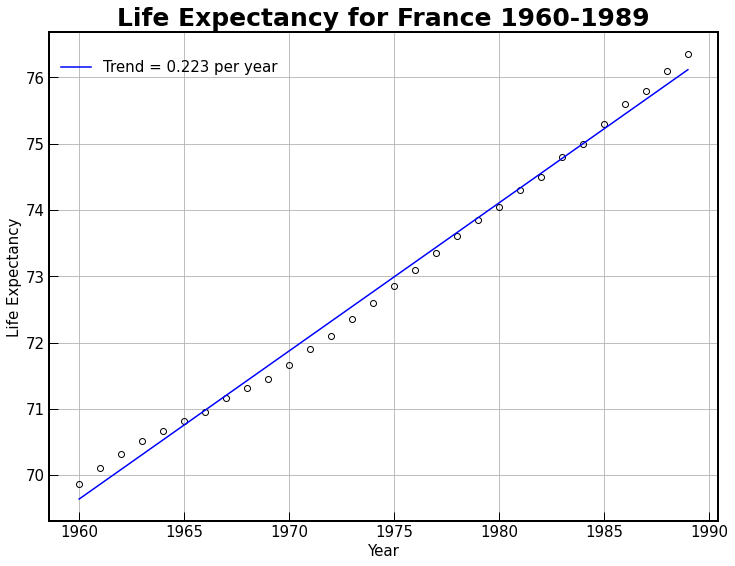

```python
#Figure 3.1
franceLine = linear_model(fTrend)
plt.figure(figsize=(12,9))
plt.plot(years, franceData, 'ko', mfc='none')
plt.plot(years, franceLine(years), 'b-',
         label=f"Trend = {fTrend[0]:.3f} per year")
plt.xlabel("Year",size=15)
plt.ylabel("Life Expectancy",size=15)
plt.tick_params(direction='in',labelsize=15)
# This allows you to modify the direction in which the 'ticks' protrude along
# the axis.

plt.legend(loc= (0.01,.9))
plt.title("Life Expectancy for France 1960-1989",fontweight="bold")
plt.grid() # creates background gridlines for each tickmark

plt.savefig("CH3;LifeExpectancyFranceTrend.jpg")
```

Now we look at a linear model between the heating degree day (HDD) and energy consumption (kWh) by month. Background information on these metrics is available in the textbook on page 36.

```python
HDD = np.array([163, 228, 343, 373, 301, 238, 137, 84, 38, 15, 14, 34])
kWh = np.array([593, 676, 1335, 1149, 1127, 892, 538, 289, 172, 131, 134, 134])

HDDbykWh = pd.DataFrame(
    data=[HDD,kWh], index=['HDD','kWh'],
    columns=['Jan', 'Feb', 'Mar', 'Apr', 'May', 'Jun',
             'Jul', 'Aug', 'Sep', 'Oct', 'Nov', 'Dec'])
# The DataFrame created above is made from data we defined instead of data from a
# file (like the one at the top of this notebook); as such, `index` and `columns`
# allows us to label the rows and columns of the DataFrame instead of extrapolating
# them from a file.

HDDbykWh
```

|  | Jan | Feb | Mar | Apr | May | Jun | Jul | Aug | Sep | Oct | Nov | Dec |
| --- | --- | --- | --- | --- | --- | --- | --- | --- | --- | --- | --- | --- |
| HDD | 163 | 228 | 343 | 373 | 301 | 238 | 137 | 84 | 38 | 15 | 14 | 34 |
| kWh | 593 | 676 | 1335 | 1149 | 1127 | 892 | 538 | 289 | 172 | 131 | 134 | 134 |

The creation of the DataFrame above was completely unnecessary for what we are going to do next and is only there to show you that you can create your own from data entered manually or data that is already stored in an array. As already mentioned, `DataFrame` has a lot of quality of life features that you are encouraged to look into yourself. The `DataFrame` API can be found [here](https://pandas.pydata.org/docs/reference/frame.html). For now, lets find the linear trend and correlation between HDD and kWh:

```python
cTrend = np.polyfit(HDD, kWh, 1)
# cTrend is our set of linear fit coefficients

R = np.corrcoef(HDD, kWh)[0,1]**2
# R is the coefficient of correlation between HDD and kWh.

plotlabel1 = (
    f"Linear Model: kWh = {cTrend[0]:1.3f}HDD + {cTrend[1]:2.3f}\n"
    f"R$^2$ = {R:.4f}"
    )
# plotlabel1 will be used as a label for the plot below.

hddLine = linear_model(cTrend)
# hddLine is a linear function that outputs the linear trend between HDD and kWh
```

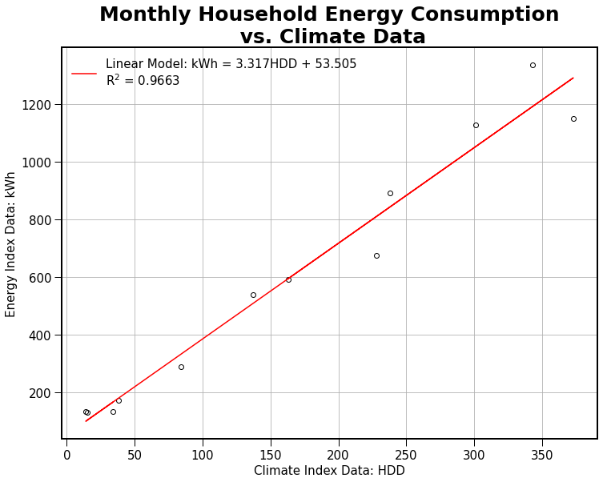

```python
#Figure 3.2
plt.figure(figsize=(12,9))
plt.plot(HDD, kWh, 'ko',mfc='none')
plt.plot(HDD, hddLine(HDD), 'r-', label=plotlabel1)
plt.xlabel("Climate Index Data: HDD",size=15)
plt.ylabel("Energy Index Data: kWh",size=15)
plt.tick_params(labelsize=15)
plt.legend(loc='upper left')
plt.title("Monthly Household Energy Consumption\n vs. Climate Data",fontweight="bold")
plt.grid()

plt.savefig("CH3;MonthlyEnergyConsumptionTrend.jpg")
```

As we've demonstrated, numpy can generate the coefficients of the linear trend for these data sets and the correlation coefficient easily. For a mathematical derivation of a linear best fit, though, please see section 3.2 (Starting on page 38) of the textbook. That section, and the following, also contain important details about data anomalies and linear estimators, as well as the geometric interpretation of 'best fit' and notes on the history of these methods. In the notebook, however, we will continue with examples of linear models on data.

Now we move onto another data set on climate change.

```python
dtmean = pd.read_csv("gl_land_oceanHansen.txt", sep="\s+", header=0, index_col=0)
# We are still using the read_csv function from pandas, but you might notice that
# the file we're reading in is not a CSV. Fear not! Pandas functions are versatile,
# and we can use the same function for this file as long as we specify the
# separator we're using to read in the data; this separator in question, sep="\s+",
# is what's known as a 'regular expression' for one or more spaces.
dtmean
```

| Year | Anomaly | mean |
| --- | --- | --- |
| 1880 | -0.20 | -99.99 |
| 1881 | -0.11 | -99.99 |
| 1882 | -0.09 | -0.17 |
| 1883 | -0.20 | -0.20 |
| 1884 | -0.27 | -0.23 |
| ... | ... | ... |
| 2010 | 0.71 | 0.62 |
| 2011 | 0.59 | 0.64 |
| 2012 | 0.62 | 0.66 |
| 2013 | 0.65 | 0.69 |
| 2014 | 0.74 | -99.99 |

135 rows × 2 columns

Now that we have the data, lets extract it for processing. Below we have a function that I wrote to display a Summary of the data of an array.

```python
def Summary(x):
    """
    This function accepts a 1-D numpy array as an argument, and uses a
    DataFrame to return a string that displays a summary of the data:
    the quantiles and the mean.
    """
    deets = np.quantile(x, [0, .25, .5, .75, 1])
    deets = np.array([np.append(deets, np.mean(x))])
    df = pd.DataFrame(data=deets,
                      columns=['Min.', '1st Qu.', 'Median',
                               '3rd Qu.', 'Max.', 'Mean'],
                      index=['values'])
    print(df.to_string())
```

The Summary function displays the quantiles and the mean of the input vector.

```python
yrstime = np.arange(1880, 2015)
dtAnom = np.array(dtmean.loc[:,'Anomaly'])
print("Summary of dtAnom:")
Summary(dtAnom)
print("Summary of yrstime;")
Summary(yrstime)
```

```
Summary of dtAnom:
        Min.  1st Qu.  Median  3rd Qu.  Max.      Mean
values -0.47    -0.21   -0.08    0.175  0.74  0.011852
Summary of yrstime;
          Min.  1st Qu.  Median  3rd Qu.    Max.    Mean
values  1880.0   1913.5  1947.0   1980.5  2014.0  1947.0
```

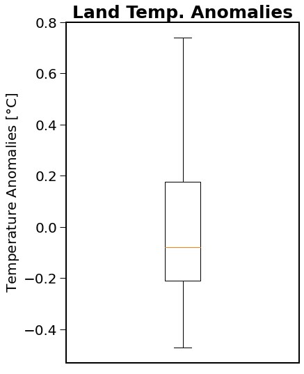

```python
#Figure 3.3
plt.figure(figsize=(6,9))
plt.boxplot(dtAnom)
plt.ylabel("Temperature Anomalies [$\degree$C]", size = 20)
plt.xticks([])
plt.tick_params(labelsize=20)
plt.title("Land Temp. Anomalies",size=25,fontweight="bold")

plt.savefig("CH3;dtAnomBoxplot.jpg", bbox_inches='tight')
# Above we have the code for a boxplot using plt.
```

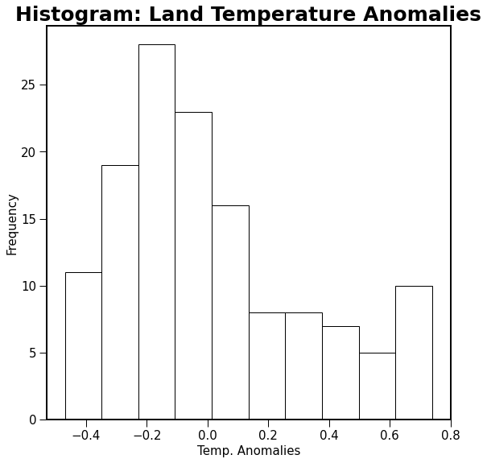

```python
#Figure 3.4
plt.figure(figsize=(9,9))
plt.hist(dtAnom, bins=10, facecolor='w', edgecolor='k', rwidth=1, align = 'mid')
# bins is the number of histogram bars, facecolor is the color of each bar,
# edgecolor is the color of the edge of each bar, rwidth is the width of each bar,
# and align lets you choose where the bars appear relative to their axis position.

plt.xlabel("Temp. Anomalies",size=15)
plt.ylabel("Frequency",size=15)
plt.tick_params(labelsize=15)
plt.title("Histogram: Land Temperature Anomalies",fontweight="bold")

plt.savefig("CH3;LandTempAnomaliesHistogram.jpg", bbox_inches='tight')
# Above we have the code for a histogram using plt.
```

```python
hTrend = np.polyfit(yrstime, dtAnom.astype(np.float), 1)
print(f"Slope of linear trend: {hTrend[0]:5.4f}, "
      f"y-intercept of linear trend: {hTrend[1]:5.2f}")
anomLine = linear_model(hTrend)
```

```
Slope of linear trend: 0.0068, y-intercept of linear trend: -13.18
```

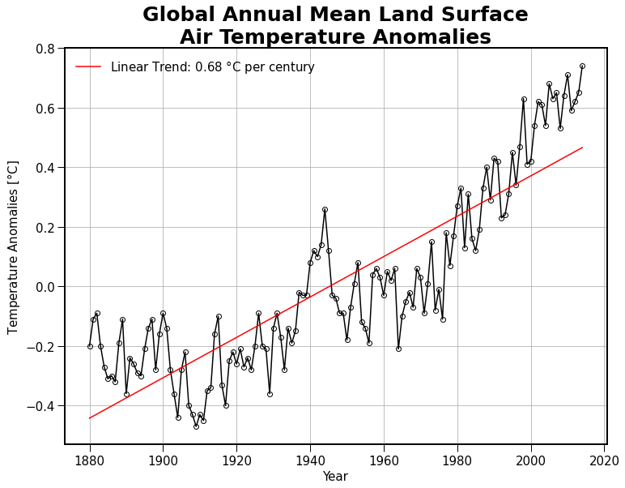

```python
#Figure 3.5
plt.figure(figsize=(12,9))
plt.plot(yrstime, dtAnom, 'ko-',mfc='none')
plt.plot(yrstime, anomLine(yrstime), 'r-',
         label=f"Linear Trend: {hTrend[0]*100:.2f} $\degree$C per century")
plt.xlabel("Year",size=15)
plt.ylabel("Temperature Anomalies [$\degree$C]",size=15)
plt.legend(loc='upper left')
plt.title("Global Annual Mean Land Surface\nAir Temperature Anomalies",fontweight="bold");
plt.tick_params(labelsize=15)
plt.grid()
plt.savefig("CH3;LandAirTempAnomaliesTrend.jpg", bbox_inches='tight')
```

We've already seen how we can get an idea of the overall trend of the data with a line of best fit, but what if we want to determine the linear trend for subsets of the data and see how the trend itself changes? That's what we'll get into next.

```python
fmt = ['b-', 'g-', 'c-', 'm-', 'r-']
indices = [31, 71, 96, 121, 150]
endyear = [1910, 1950, 1975, 2000, 2014]
# These lists contain bits of data that we'll loop through in the for loop below.
# Unlike the already touched on numpy arrays.
```

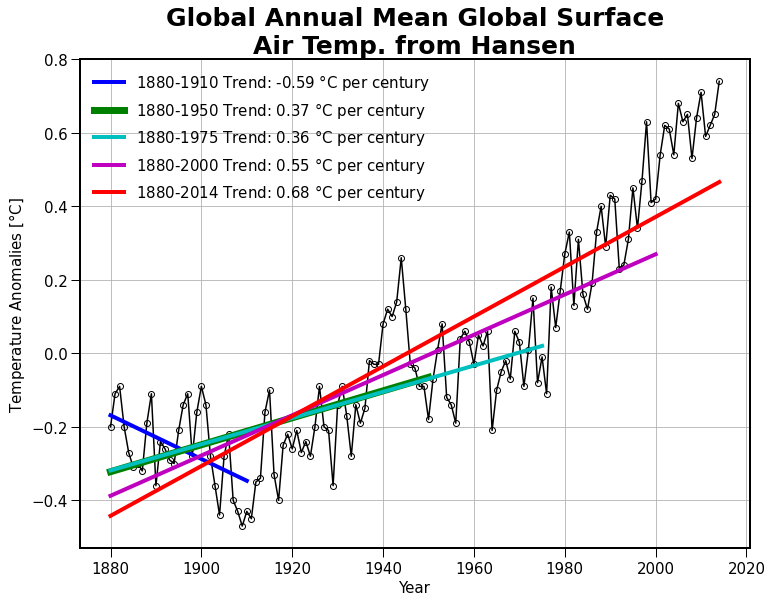

```python
#Figure 3.5
plt.figure(figsize=(12,9))
plt.plot(yrstime, dtAnom, 'ko-',mfc='none')

for (col, i, year) in zip(fmt, indices, endyear):
    mTrend = np.polyfit(yrstime[:i], dtAnom.astype(float)[:i], 1)
    temporalLine = linear_model(mTrend)
    lab = f"1880-{year} Trend: {mTrend[0]*100:.2f} $\degree$C per century"
    plt.plot(yrstime[:i], temporalLine(yrstime[:i]), col,
             linewidth=7 if year == 1950 else 4, label=lab)
    #increase linewidth for easier visibility of lines with similar trends
# zip() allows you to take an arbitrary number of iterables and turn them
# into one list of tuples element by element; which allows you to have
# multiple for loop indices.

plt.xlabel("Year",size=15)
plt.ylabel("Temperature Anomalies [$\degree$C]",size=15)
plt.legend(loc='upper left')
plt.title("Global Annual Mean Global Surface\nAir Temp. from Hansen",fontweight="bold");
plt.tick_params(labelsize=15)
plt.grid()
plt.savefig("CH3;VariableLandAirTempAnomaliesTrend.jpg", bbox_inches='tight')
```